# Honors Thesis Progress

Joel Ramirez Jr

7/1/2020

# A Day in the Life of a Child…(on average)

A childs day to day unordered AWC profile would look something like this. Where time is in military time just for the simplicity in plotting. We do see that it is very variable and also has a large window of talk, starting from 8 am to about 7pm. With AWC ranging from 0 words to 667 words within a 5 minute window.

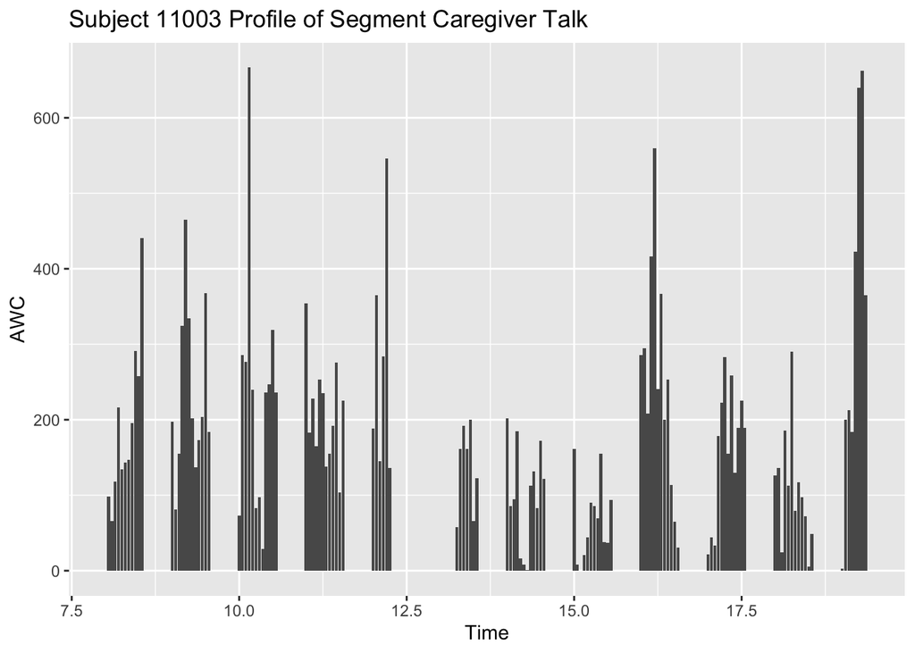

# So, where is talk happening?

First we have the unclean LENA histogram across all subjects. Observations:

- There are two big dense periods throughout the day
- These periods are in the morning and in the evening, maybe due to parents coming and going from work?

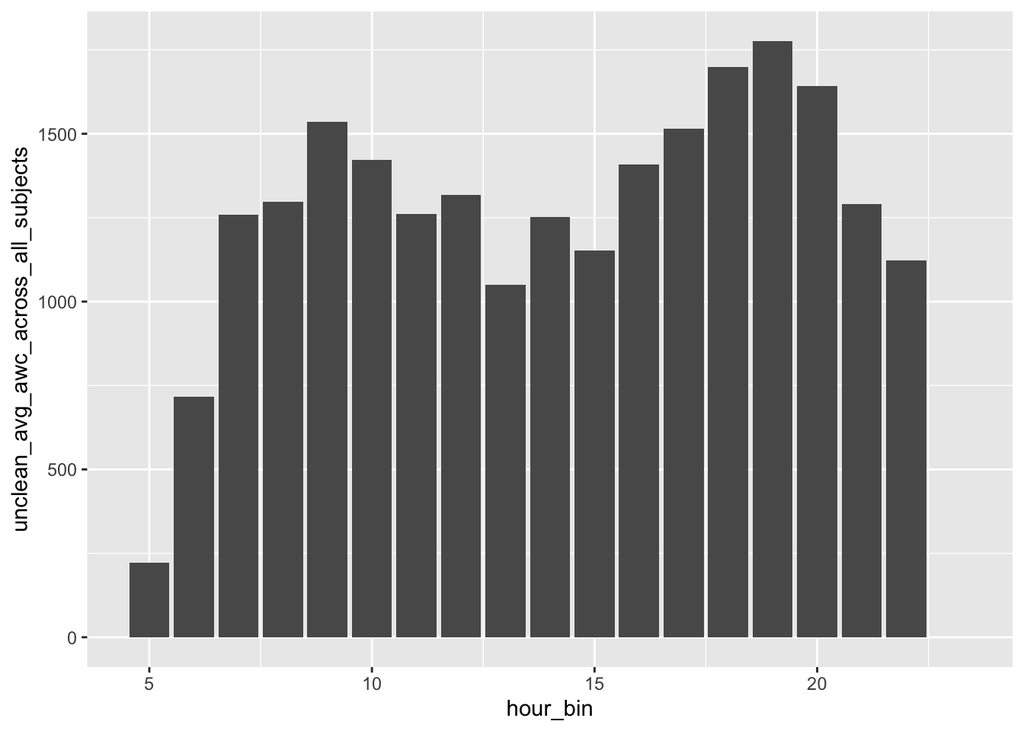

## Cleaning for Naps

Cleaning for naps is basically getting rid of all instances where the child is sleeping. This decision was made as for the two samples which we are comparing, the Spanish group turned off the recorders when the child slept or sometimes for some window within the day. So, to make it comparible we get rid of instances when children are sleeping and/or napping.

# Mean AWC with Standard Deviation of Mean AWC

The first plot is unclean mean awc X unclean standard deviation. These are measures for AWC without cleaning for naps.

The second plot is clean mean awc X clean standard deviation.

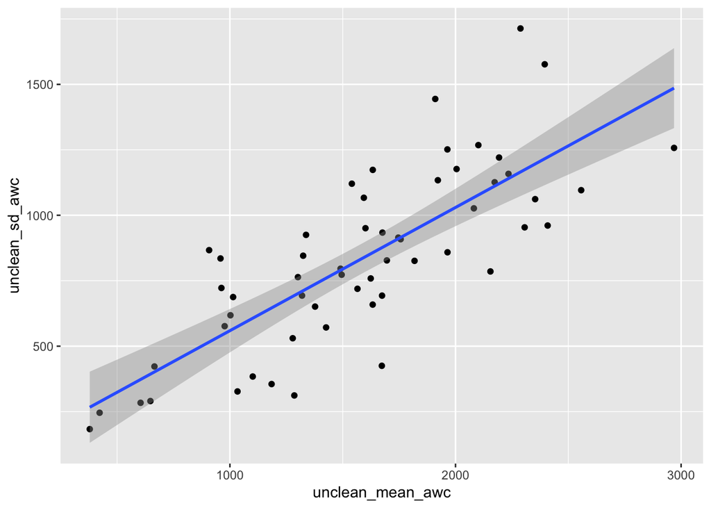

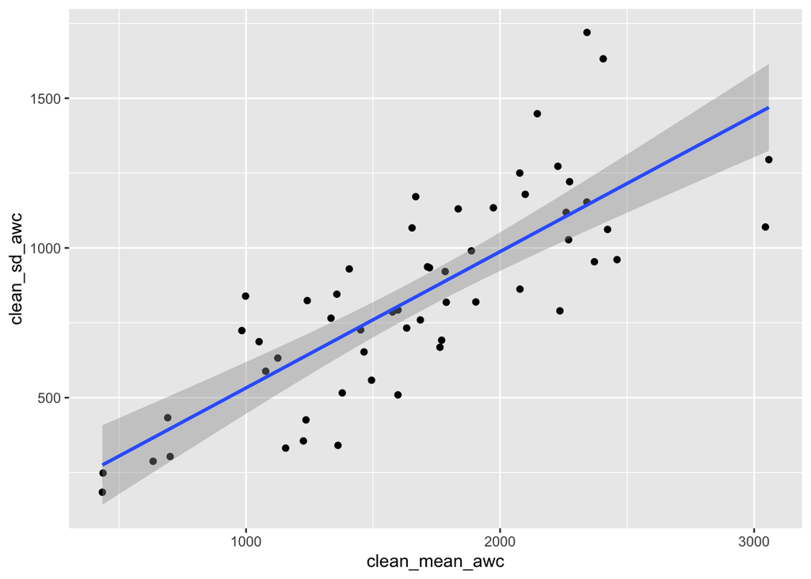

# Proportional Drop

Proportional drop was a measure we came up with to measure variance in the child’s moment-to-moment language environment. In a list of AWCs, orderd from smalled to largest where $AWC_i \geq AWC_{i=1}$, for a single child, proportional drop for two single observations can be seen as $P\Delta = 1 - AWC_{i-1}/AWC_i$ where $AWC_{i-1}/AWC_i$ is the percentage of AWC from one drop to the other. And, so to see the proportional drop we take $1 - AWC_{i-1}/AWC_i$ to get the proportional difference between the $i^{th}$ and $i^{th}-1$.

We used two measures:

- average proportional drop across the day
- max drop throughout the day

Observations: We saw that every child had at least two contiguous segments with the same AWC count. Thus, all children had a mininum drop of 0.

Here we see the histogram proportional drop across the entire day as well as a summary of its statistics.

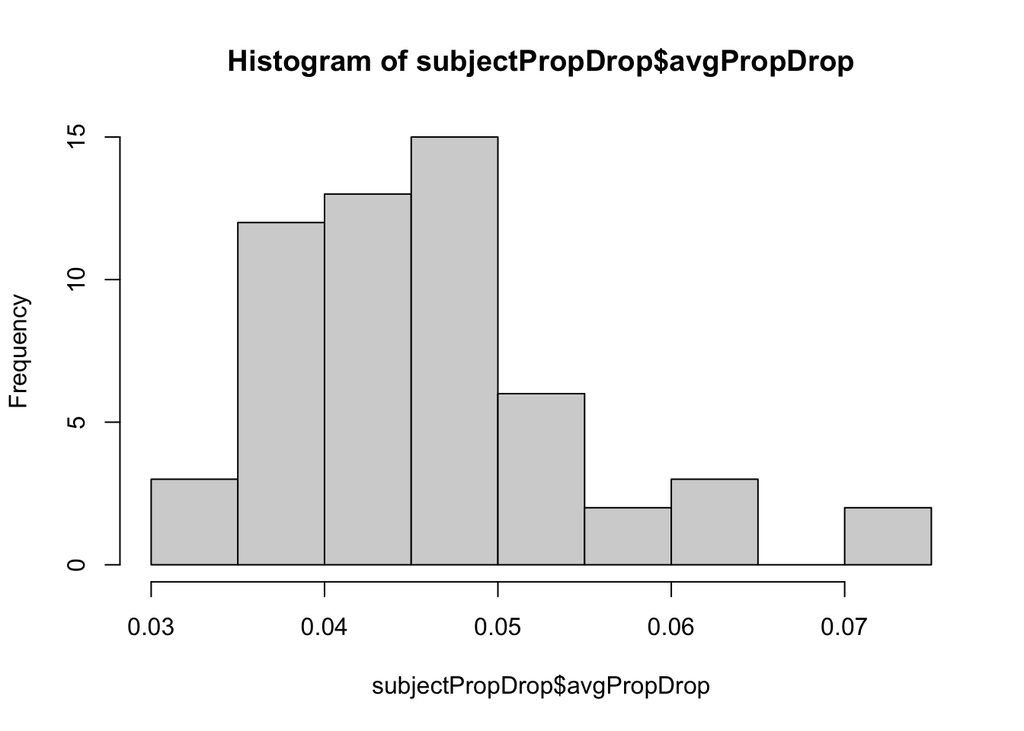

```
##    Min. 1st Qu.  Median    Mean 3rd Qu.    Max.
## 0.03125 0.03995 0.04500 0.04597 0.04846 0.07396
```

Here are side by side graphs of average proportional drop against clean mean AWC and standard deviation AWC.

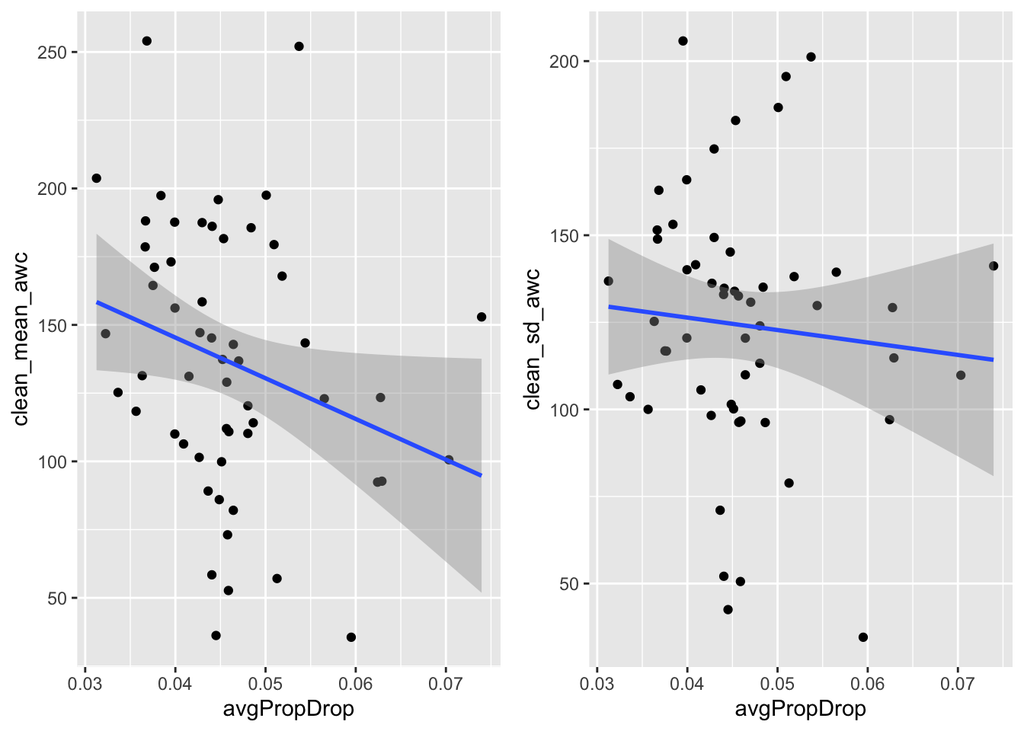

Here are side by side graphs of max proportional drop against clean mean AWC and standard deviation AWC. We see that they are not correlated at all and so at this point we decided to leave the measure alone.

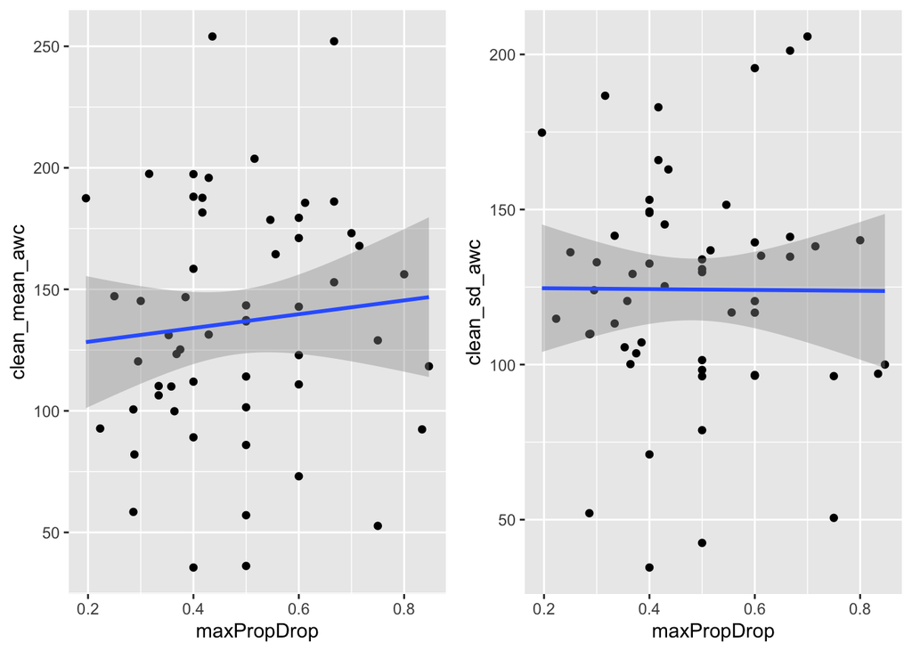

# Clustering Measures

As we saw before, the language landscape of a child is very variable throughout the day. So how to we simplify this?

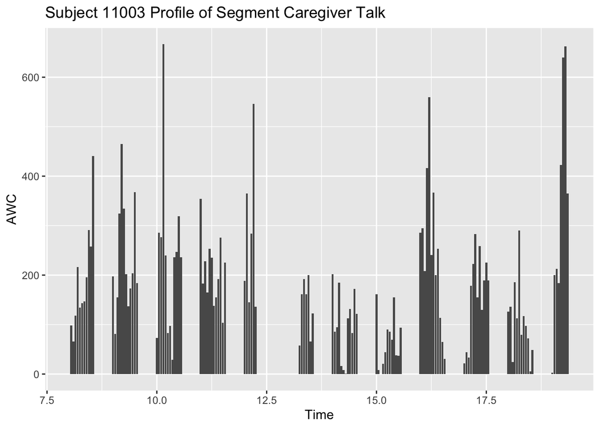

To find periods of dense talk, we identified the highest 30% of AWC segments for each family, and then applied a k-means clustering algorithm to identify one or more consecutive 5 minute segments that were similar in AWC (i.e., clusters of talk).

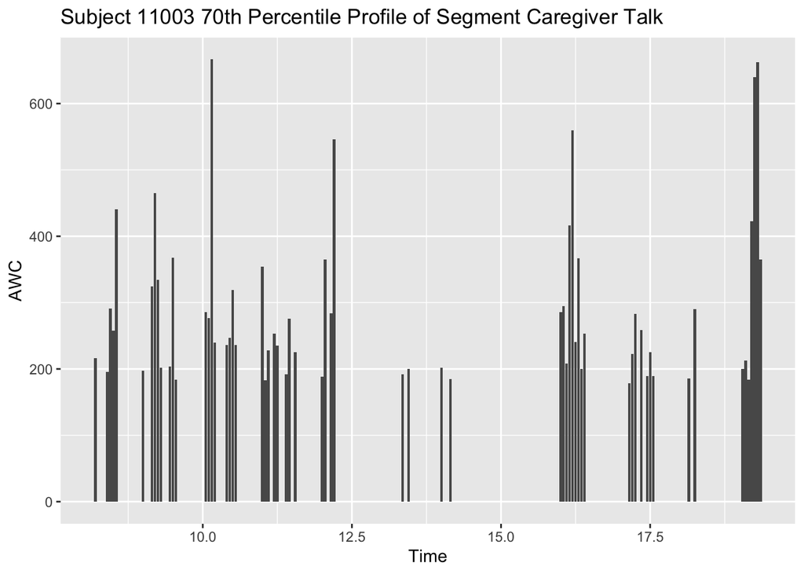

Thus, it simplifies the work we have to do by only looking at the top 30th percentile of AWCs for each child and also helps us better see the amounts of peaks a child has throughout the day. So when we run a kmeans custering algorithm, we run it on these top 30th percentile awcs for each child respectively.

# K-Means Clustering

k-means clustering is a method of vector quantization, originally from signal processing, that aims to partition n observations into k clusters in which each observation belongs to the cluster with the nearest mean (cluster centers or cluster centroid), serving as a prototype of the cluster.

Given a set of observations $(x_1, x_2, ..., x_n)$, where each observation is a d-dimensional real vector, k-means clustering aims to partition the $n$ observations into $k (\leq n)$ sets $S = {S_1, S_2, ..., S_k}$ so as to minimize the within-cluster sum of squares (WCSS) (i.e. variance). Formally, the objective is to find:

${\displaystyle {\underset {\mathbf {S} }{\operatorname {arg\,min} }}\sum _{i=1}^{k}\sum _{\mathbf {x} \in S_{i}}\left\|\mathbf {x} -{\boldsymbol {\mu }}_{i}\right\|^{2}={\underset {\mathbf {S} }{\operatorname {arg\,min} }}\sum _{i=1}^{k}|S_{i}|\operatorname {Var} S_{i}}$

Using the K-means clustering approach, we found these statistics.

- Range(0, 35) in the number of clusters found for each child. We are currently investigating why this number is so high.
- Mean number of of clusters is approximately 13.9.
- Average cluster Size (i.e. duration) was 2.07. This means that each cluster was approximately 10 minutes long.

To take into account differences in recording length, which had a range of 5 to 12 full hours (clean), we made the number of clusters a rate per hour. Current statistics are as follows:

- Mean: 1.413 clusters per hour.
- Median: 1.352 clusters per hour

Clusters per hour turned out to correlate significantly with Mean AWC and Standard Deviation of Average AWC.

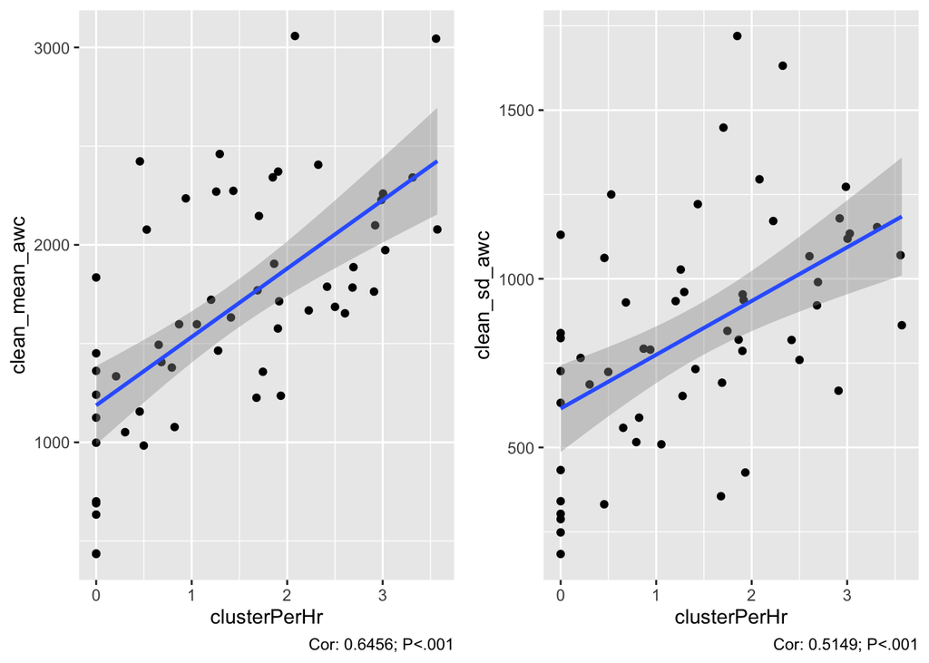

Average cluster size was found not to correlate with AWC or number of clusters as we see below.

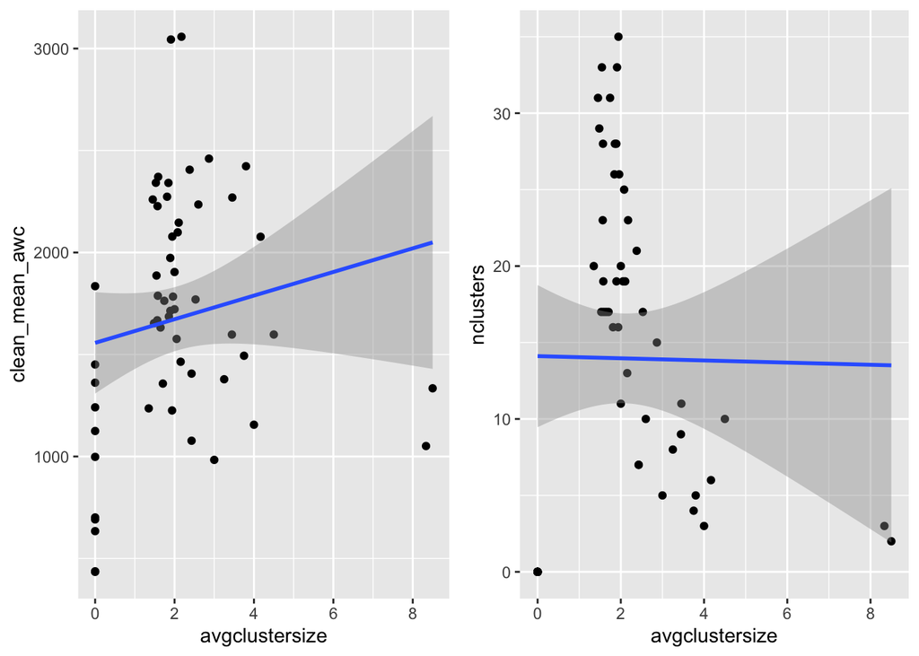

Next, we want to look at how these measures predict to later language outcomes.